# Introduction to Python Project : FoodHub Data Analysis

### Problem Statement

The rapid growth in the number of restaurants in New York, combined with the busy lifestyles of students and working professionals, has led to an increased dependence on online food delivery services. FoodHub, a food aggregator platform, provides customers with convenient access to multiple restaurants through a single smartphone application while enabling restaurants to receive and fulfill online orders efficiently.

Despite the convenience offered, managing order fulfillment, delivery efficiency, customer satisfaction, and restaurant performance remains a significant challenge for FoodHub. The platform generates large volumes of data related to customer orders, restaurant operations, delivery times, order costs, and customer ratings. However, without proper analysis, this data cannot be effectively utilized to improve operational efficiency, enhance customer experience, or optimize service quality.

Therefore, there is a need to analyze FoodHub’s order data to understand customer behavior, restaurant performance, and delivery dynamics in order to support data-driven decision-making and improve overall platform performance.

### Objectives

The food aggregator company has stored the data of the different orders made by the registered customers in their online portal. They want to analyze the data to get a fair idea about the demand of different restaurants which will help them in enhancing their customer experience. Suppose you are hired as a Data Scientist in this company and the Data Science team has shared some of the key questions that need to be answered. Perform the data analysis to find answers to these questions that will help the company improve its business.

### Data Dictionary

1. order_id: Unique identifier for each order.
2. customer_id: Unique ID of the customer placing the order.
3. restaurant_name: Name of the restaurant from which the order was placed.
4. cuisine_type: Type of cuisine ordered.
5. cost_of_the_order: Total cost of the food order.
6. day_of_the_week: Indicates whether the order was placed on a weekday or weekend.
7. rating: Customer rating for the order (out of 5).
8. food_preparation_time: Time (in minutes) taken by the restaurant to prepare the food.
9. delivery_time: Time (in minutes) taken by the delivery partner to deliver the order.

### Let us start by importing the required libraries

```python
import pandas as pd
import matplotlib.pyplot as plt
import seaborn as sns
```

### Understanding the structure of the data

```python
# Mount Google Drive
from google.colab import drive
drive.mount('/content/drive')
```

```python
# Reading the foodhub_order dataset
df=pd.read_csv('/content/drive/MyDrive/foodhub_order.csv')
df
```

|  | order_id | customer_id | restaurant_name | cuisine_type | cost_of_the_order | day_of_the_week | rating | food_preparation_time | delivery_time |
| --- | --- | --- | --- | --- | --- | --- | --- | --- | --- |
| 0 | 1477147 | 337525 | Hangawi | Korean | 30.75 | Weekend | Not given | 25 | 20 |
| 1 | 1477685 | 358141 | Blue Ribbon Sushi Izakaya | Japanese | 12.08 | Weekend | Not given | 25 | 23 |
| 2 | 1477070 | 66393 | Cafe Habana | Mexican | 12.23 | Weekday | 5 | 23 | 28 |
| 3 | 1477334 | 106968 | Blue Ribbon Fried Chicken | American | 29.20 | Weekend | 3 | 25 | 15 |
| 4 | 1478249 | 76942 | Dirty Bird to Go | American | 11.59 | Weekday | 4 | 25 | 24 |
| ... | ... | ... | ... | ... | ... | ... | ... | ... | ... |
| 1893 | 1476701 | 292602 | Chipotle Mexican Grill $1.99 Delivery | Mexican | 22.31 | Weekend | 5 | 31 | 17 |
| 1894 | 1477421 | 397537 | The Smile | American | 12.18 | Weekend | 5 | 31 | 19 |
| 1895 | 1477819 | 35309 | Blue Ribbon Sushi | Japanese | 25.22 | Weekday | Not given | 31 | 24 |
| 1896 | 1477513 | 64151 | Jack's Wife Freda | Mediterranean | 12.18 | Weekday | 5 | 23 | 31 |
| 1897 | 1478056 | 120353 | Blue Ribbon Sushi | Japanese | 19.45 | Weekend | Not given | 28 | 24 |

1898 rows × 9 columns

```python
# Display the first five rows
df.head()
```

|  | order_id | customer_id | restaurant_name | cuisine_type | cost_of_the_order | day_of_the_week | rating | food_preparation_time | delivery_time |
| --- | --- | --- | --- | --- | --- | --- | --- | --- | --- |
| 0 | 1477147 | 337525 | Hangawi | Korean | 30.75 | Weekend | Not given | 25 | 20 |
| 1 | 1477685 | 358141 | Blue Ribbon Sushi Izakaya | Japanese | 12.08 | Weekend | Not given | 25 | 23 |
| 2 | 1477070 | 66393 | Cafe Habana | Mexican | 12.23 | Weekday | 5 | 23 | 28 |
| 3 | 1477334 | 106968 | Blue Ribbon Fried Chicken | American | 29.20 | Weekend | 3 | 25 | 15 |
| 4 | 1478249 | 76942 | Dirty Bird to Go | American | 11.59 | Weekday | 4 | 25 | 24 |

### **Question 1:** How many rows and columns are present in the data? [0.5 mark]

```python
df.shape
```

```
(1898, 9)
```

#### Observations:

There are 1898 rows and 9 columns in the data

### **Question 2:** What are the datatypes of the different columns in the dataset? (The info() function can be used) [0.5 mark]

```python
#method 1: Checking types of datatypes
print(df.dtypes)

#method 2: Checking types of datatypes
df.info()
```

```
order_id                   int64
customer_id                int64
restaurant_name           object
cuisine_type              object
cost_of_the_order        float64
day_of_the_week           object
rating                    object
food_preparation_time      int64
delivery_time              int64
dtype: object
<class 'pandas.core.frame.DataFrame'>
RangeIndex: 1898 entries, 0 to 1897
Data columns (total 9 columns):
 #   Column                 Non-Null Count  Dtype
---  ------                 --------------  -----
 0   order_id               1898 non-null   int64
 1   customer_id            1898 non-null   int64
 2   restaurant_name        1898 non-null   object
 3   cuisine_type           1898 non-null   object
 4   cost_of_the_order      1898 non-null   float64
 5   day_of_the_week        1898 non-null   object
 6   rating                 1898 non-null   object
 7   food_preparation_time  1898 non-null   int64
 8   delivery_time          1898 non-null   int64
dtypes: float64(1), int64(4), object(4)
memory usage: 133.6+ KB
```

#### Observations:

It has found that there are three datatypes : int64, object, float64

### **Question 3:** Are there any missing values in the data? If yes, treat them using an appropriate method. [1 mark]

```python
#Checking null values in each column
df.isna().sum()
```

|  | 0 |
| --- | --- |
| order_id | 0 |
| customer_id | 0 |
| restaurant_name | 0 |
| cuisine_type | 0 |
| cost_of_the_order | 0 |
| day_of_the_week | 0 |
| rating | 0 |
| food_preparation_time | 0 |
| delivery_time | 0 |

**dtype:** int64

#### Observations:

No null values found here in the dataset

### **Question 4:** Check the statistical summary of the data. What is the minimum, average, and maximum time it takes for food to be prepared once an order is placed? [2 marks]

```python
#statistical summary of the data
df.describe()
```

|  | order_id | customer_id | cost_of_the_order | food_preparation_time | delivery_time |
| --- | --- | --- | --- | --- | --- |
| count | 1.898000e+03 | 1898.000000 | 1898.000000 | 1898.000000 | 1898.000000 |
| mean | 1.477496e+06 | 171168.478398 | 16.498851 | 27.371970 | 24.161749 |
| std | 5.480497e+02 | 113698.139743 | 7.483812 | 4.632481 | 4.972637 |
| min | 1.476547e+06 | 1311.000000 | 4.470000 | 20.000000 | 15.000000 |
| 25% | 1.477021e+06 | 77787.750000 | 12.080000 | 23.000000 | 20.000000 |
| 50% | 1.477496e+06 | 128600.000000 | 14.140000 | 27.000000 | 25.000000 |
| 75% | 1.477970e+06 | 270525.000000 | 22.297500 | 31.000000 | 28.000000 |
| max | 1.478444e+06 | 405334.000000 | 35.410000 | 35.000000 | 33.000000 |

#### Observations:

After statistical infromation, values for food preparation time are as follows:

min time =20.000000

average time= 27.371970

max time= 35.000000

### **Question 5:** How many orders are not rated? [1 mark]

```python
print(df['rating'].value_counts())
```

```
rating
Not given    736
5            588
4            386
3            188
Name: count, dtype: int64
```

#### Observations:

There are 736 orders that are not rated as ['Not given']

### Exploratory Data Analysis (EDA)

### **Question 6:** Explore all the variables and provide observations on their distributions. (Generally, histograms, boxplots, countplots, etc. are used for univariate exploration.) [9 marks]

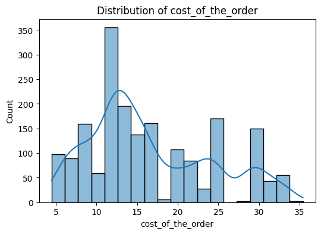

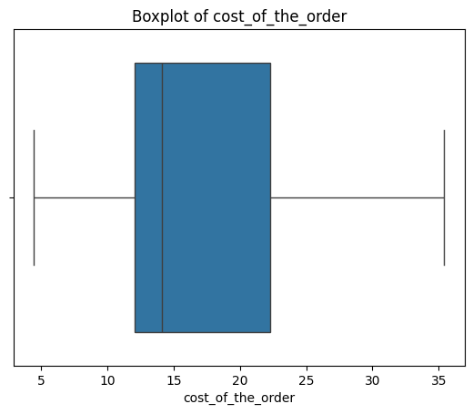

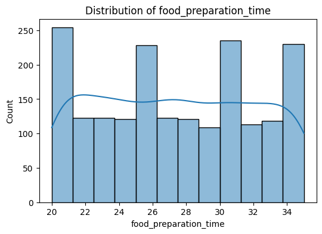

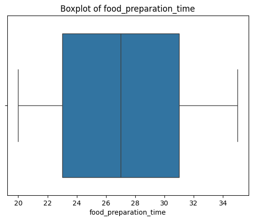

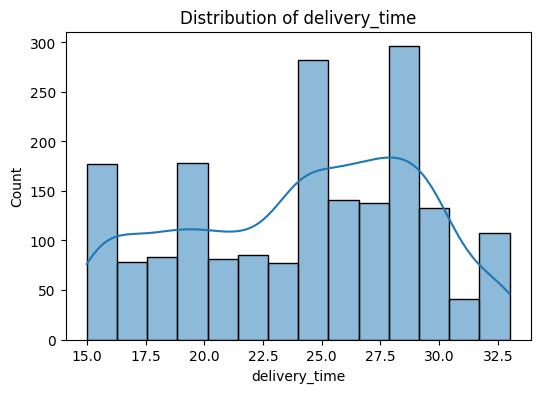

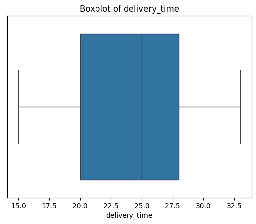

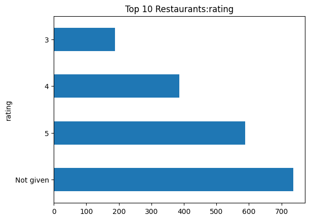

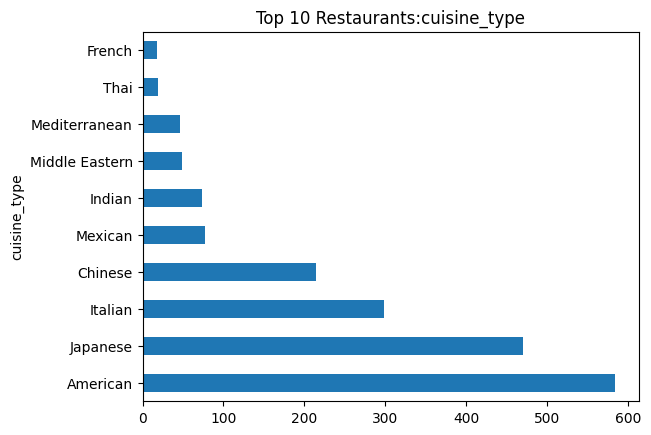

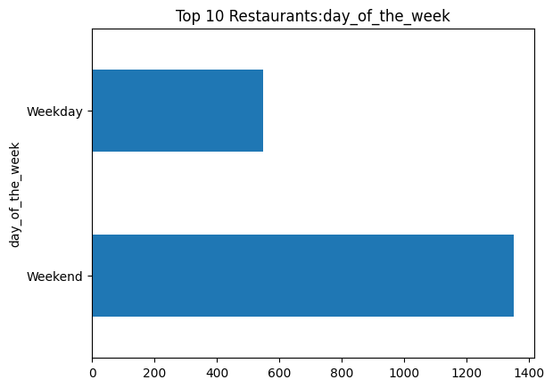

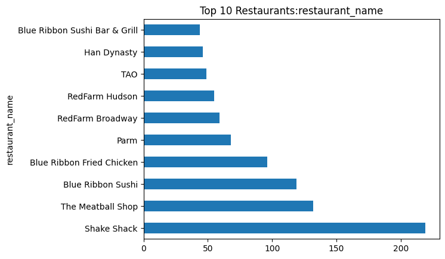

```python
# # Numerical variables that are significant
#univariate Analysis for Numerical data
num_vars = ['cost_of_the_order', 'food_preparation_time', 'delivery_time']

for col in num_vars:
    plt.figure(figsize=(6,4))
    sns.histplot(df[col], kde=True)
    plt.title(f'Distribution of {col}')
    plt.show()

    sns.boxplot(x=df[col])
    plt.title(f'Boxplot of {col}')
    plt.show()



#Univariate analysis for categorical data
num_vars = ['rating', 'cuisine_type', 'day_of_the_week','restaurant_name']
for col in num_vars:
    df[col].value_counts().head(10).plot(kind='barh')
    plt.title(f'Top 10 Restaurants:{col}')
    plt.show()
```

### **Question 7**: Which are the top 5 restaurants in terms of the number of orders received? [1 mark]

```python
top_5_restaurants = df['restaurant_name'].value_counts().head(5)
top_5_restaurants
```

| restaurant_name | count |
| --- | --- |
| Shake Shack | 219 |
| The Meatball Shop | 132 |
| Blue Ribbon Sushi | 119 |
| Blue Ribbon Fried Chicken | 96 |
| Parm | 68 |

**dtype:** int64

#### Observations:

Top 5 restuarants in terms of orders are:

Shake Shack with 219 orders

The Meatball Shop with 132 orders

Blue Ribbon Sushi with 119 orders

Blue Ribbon Fried Chicken with 96 orders

Parm with 68 orders

### **Question 8**: Which is the most popular cuisine on weekends? [1 mark]

```python
df.groupby('day_of_the_week')['cuisine_type'].value_counts()
```

| day_of_the_week | cuisine_type | count |
| --- | --- | --- |
| Weekday | American | 169 |
|  | Japanese | 135 |
|  | Italian | 91 |
|  | Chinese | 52 |
|  | Indian | 24 |
|  | Mexican | 24 |
|  | Middle Eastern | 17 |
|  | Mediterranean | 14 |
|  | Southern | 6 |
|  | French | 5 |
|  | Thai | 4 |
|  | Vietnamese | 3 |
|  | Korean | 2 |
|  | Spanish | 1 |
| Weekend | American | 415 |
|  | Japanese | 335 |
|  | Italian | 207 |
|  | Chinese | 163 |
|  | Mexican | 53 |
|  | Indian | 49 |
|  | Mediterranean | 32 |
|  | Middle Eastern | 32 |
|  | Thai | 15 |
|  | French | 13 |
|  | Korean | 11 |
|  | Southern | 11 |
|  | Spanish | 11 |
|  | Vietnamese | 4 |

**dtype:** int64

#### Observations:

The most popular cuisine on weekend is American cuisine

### **Question 9**: What percentage of the orders cost more than 20 dollars? [2 marks]

```python
mean_delivery_time = df['delivery_time'].mean()
mean_delivery_time

total_orders = len(df)
count_orders= (df['cost_of_the_order']>20).sum()

percentage = (count_orders / total_orders) * 100
percentage
```

```
np.float64(29.24130663856691)
```

#### Observations:

Total Percentage of orders cost more than 20 dollars is 29.24 %

### **Question 10**: What is the mean order delivery time? [1 mark]

```python
Mean_order_delivery_time=df['delivery_time'].mean()
print (Mean_order_delivery_time)
```

```
24.161749209694417
```

#### Observations:

The mean order delivery time is 24.161749209694417

### **Question 11:** The company has decided to give 20% discount vouchers to the top 3 most frequent customers. Find the IDs of these customers and the number of orders they placed. [1 mark]

```python
Num_order_counts=df['customer_id'].value_counts().rename('customer_order').head(3)
Num_order_counts
```

| customer_id | customer_order |
| --- | --- |
| 52832 | 13 |
| 47440 | 10 |
| 83287 | 9 |

**dtype:** int64

#### Observations:

Top three customer ids(no of orders) : 52832(13), 47440(10),83287(9)

### **Question 12**: Perform a multivariate analysis to explore relationships between the important variables in the dataset. (It is a good idea to explore relations between numerical variables as well as relations between numerical and categorical variables) [10 marks]

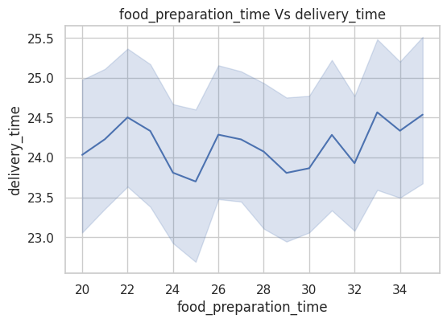

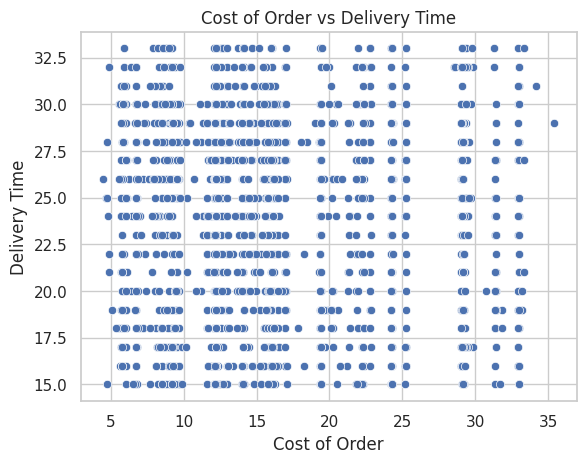

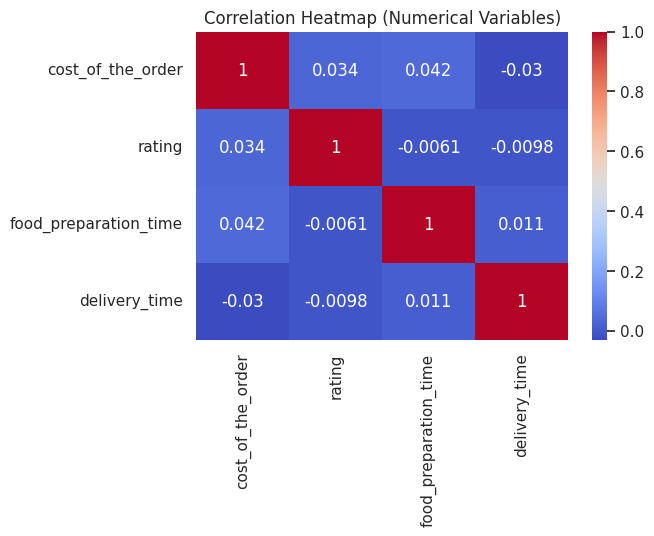

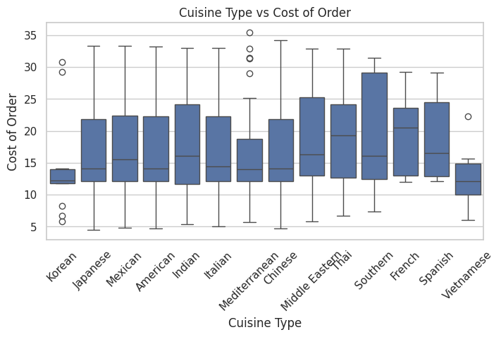

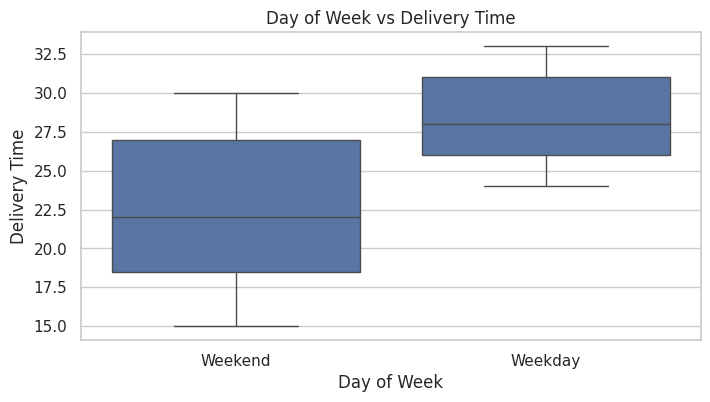

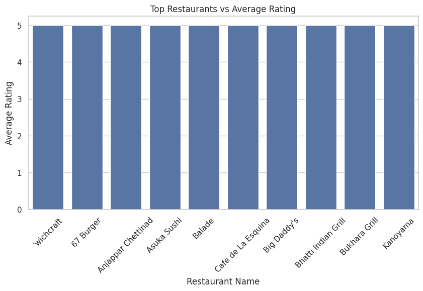

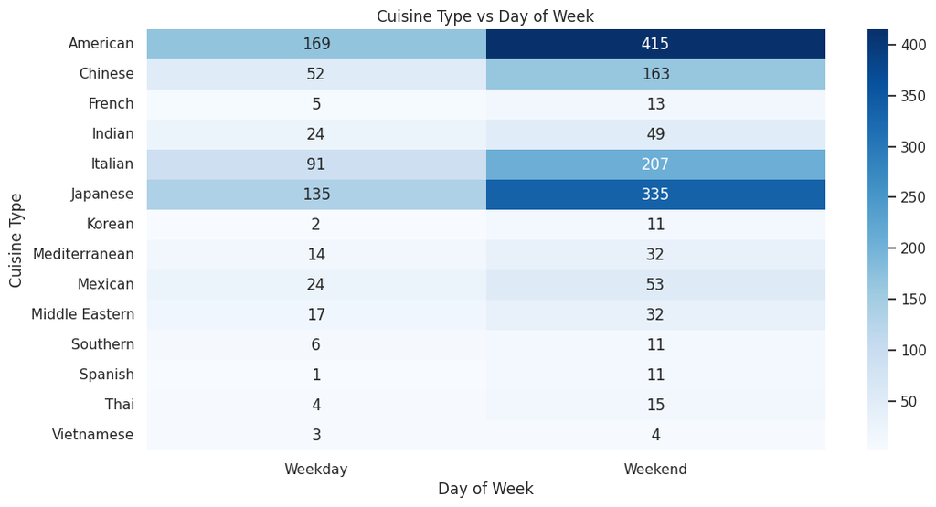

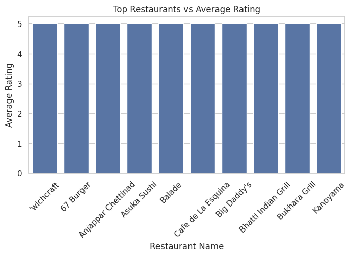

```python
#Multivariate analysis
#Numerical Relationships
#1.Food preparation time vs delivery time

sns.set(style='whitegrid')
plt.figure(figsize=(6,4))
sns.lineplot(data=df, x=df['food_preparation_time'], y=df['delivery_time'])
plt.title('food_preparation_time Vs delivery_time')
plt.xlabel('food_preparation_time')
plt.ylabel('delivery_time')
plt.show()


#2. Scatter Plot: Cost of Order vs Delivery Time
sns.scatterplot(data=df, x='cost_of_the_order', y='delivery_time')
plt.title("Cost of Order vs Delivery Time")
plt.xlabel("Cost of Order")
plt.ylabel("Delivery Time")
plt.show()


#3. Correlation Heatmap of Numerical Variables
import numpy as np
numerical_cols = ['cost_of_the_order', 'rating', 'food_preparation_time', 'delivery_time']
df[numerical_cols] = df[numerical_cols].replace("Not given", np.nan)
plt.figure(figsize=(6,4))
sns.heatmap(df[numerical_cols].corr(), annot=True, cmap='coolwarm')
plt.title("Correlation Heatmap (Numerical Variables)")
plt.show()



#Numerical Vs Categorical Analysis
#4.Cuisine Type vs Cost of Order (Boxplot)
plt.figure(figsize=(8,4))
sns.boxplot(x='cuisine_type', y='cost_of_the_order', data=df)
plt.title('Cuisine Type vs Cost of Order')
plt.xlabel('Cuisine Type')
plt.ylabel('Cost of Order')
plt.xticks(rotation=45)
plt.show()


#5.Day of Week vs Delivery Time (Boxplot)
plt.figure(figsize=(8,4))
sns.boxplot(x='day_of_the_week', y='delivery_time', data=df)
plt.title('Day of Week vs Delivery Time')
plt.xlabel('Day of Week')
plt.ylabel('Delivery Time')
plt.show()

#6.Restaurant Name vs Rating (Barplot)
df['rating'] = pd.to_numeric(df['rating'], errors='coerce')
df_clean = df.dropna(subset=['rating'])
top_restaurants = df_clean.groupby('restaurant_name')['rating'].mean().sort_values(ascending=False).head(10)
plt.figure(figsize=(10,5))
sns.barplot(x=top_restaurants.index, y=top_restaurants.values)
plt.title('Top Restaurants vs Average Rating')
plt.xlabel('Restaurant Name')
plt.ylabel('Average Rating')
plt.xticks(rotation=45)
plt.show()



#7. cat vs cat relationship
#Cuisine Type vs Day of Week (Heatmap / Crosstab)
# Create crosstab (counts for each cuisine type per day)
crosstab = pd.crosstab(df['cuisine_type'], df['day_of_the_week'])
plt.figure(figsize=(12,6))
sns.heatmap(crosstab, annot=True, fmt='d', cmap='Blues')
plt.title('Cuisine Type vs Day of Week')
plt.xlabel('Day of Week')
plt.ylabel('Cuisine Type')
plt.show()





#8.Customer ID vs Cuisine Type
# Countplot for Top 5 Frequent Customers
df['rating'] = pd.to_numeric(df['rating'], errors='coerce')
top_restaurants = df.groupby('restaurant_name')['rating'].mean().sort_values(ascending=False).head(10)
plt.figure(figsize=(8,4))
sns.barplot(x=top_restaurants.index, y=top_restaurants.values)
plt.title('Top Restaurants vs Average Rating')
plt.xlabel('Restaurant Name')
plt.ylabel('Average Rating')
plt.xticks(rotation=45)
plt.show()
```

### **Question 13:** The company wants to provide a promotional offer in the advertisement of the restaurants. The condition to get the offer is that the restaurants must have a rating count of more than 50 and the average rating should be greater than 4. Find the restaurants fulfilling the criteria to get the promotional offer. [3 marks]

```python
df['rating'] = pd.to_numeric(df['rating'], errors='coerce')
df = df.dropna(subset=['rating'])
restaurant_stats = df.groupby('restaurant_name')['rating'].agg(
    rating_count='count',
    average_rating='mean'
)

eligible_restaurants = restaurant_stats[
    (restaurant_stats['rating_count'] > 50) &
    (restaurant_stats['average_rating'] > 4)
]


print(eligible_restaurants)
```

```
                           rating_count  average_rating
restaurant_name
Blue Ribbon Fried Chicken            64        4.328125
Blue Ribbon Sushi                    73        4.219178
Shake Shack                         133        4.278195
The Meatball Shop                    84        4.511905
```

#### Observations:

Blue Ribbon Fried Chicken ,Blue Ribbon Sushi,Shake Shack and The Meatball Shop are the restaurants that have a rating count of more than 50 and the average rating should be greater than 4. These restaurants fulfill the criteria to get the promotional offer.

### **Question 14:** The company charges the restaurant 25% on the orders having cost greater than 20 dollars and 15% on the orders having cost greater than 5 dollars. Find the net revenue generated by the company across all orders. [3 marks]

```python
df['cost_of_the_order'] = pd.to_numeric(df['cost_of_the_order'], errors='coerce')
df['revenue'] = 0
df.loc[df['cost_of_the_order'] > 20, 'revenue'] = df['cost_of_the_order'] * 0.25
df.loc[(df['cost_of_the_order'] > 5) & (df['cost_of_the_order'] <= 20), 'revenue'] = df['cost_of_the_order'] * 0.15

# Calculate total revenue
total_revenue = df['revenue'].sum()

print("Net revenue generated by the company:", total_revenue)
```

```
Net revenue generated by the company: 3865.572
```

[output not shown]

### **Question 15:** The company wants to analyze the total time required to deliver the food. What percentage of orders take more than 60 minutes to get delivered from the time the order is placed? (The food has to be prepared and then delivered.) [2 marks]

```python
df['food_preparation_time'] = pd.to_numeric(df['food_preparation_time'], errors='coerce')
df['delivery_time'] = pd.to_numeric(df['delivery_time'], errors='coerce')

df = df.dropna(subset=['food_preparation_time', 'delivery_time'])

df['total_time'] = df['food_preparation_time'] + df['delivery_time']
total_orders = len(df)
late_orders = len(df[df['total_time'] > 60])

percentage = (late_orders / total_orders) * 100

print("Percentage of orders taking more than 60 minutes:", round(percentage, 2), "%")
```

```
Percentage of orders taking more than 60 minutes: 10.24 %
```

### **Question 16:** The company wants to analyze the delivery time of the orders on weekdays and weekends. How does the mean delivery time vary during weekdays and weekends? [2 marks]

```python
df['delivery_time'] = pd.to_numeric(df['delivery_time'], errors='coerce')
df = df.dropna(subset=['delivery_time'])

# Calculate mean delivery time
mean_delivery = df.groupby('day_of_the_week')['delivery_time'].mean()

print(mean_delivery)
```

```
day_of_the_week
Weekday    28.305882
Weekend    22.436740
Name: delivery_time, dtype: float64
```

#### Observations:

The delivery time changes by 5.869142 from weekday to weekend. On weekends delivery time is less than weekdays.

### Conclusion and Recommendations

### **Question 17:** What are your conclusions from the analysis? What recommendations would you like to share to help improve the business? (You can use cuisine type and feedback ratings to drive your business recommendations.) [6 marks]

### Conclusions:

Restaurants with higher average ratings and a large number of reviews perform consistently better.Only a limited number of restaurants meet both conditions of high rating count (>50) and average rating (>4), indicating quality differentiation.

Orders with higher cost (>20 dollars) contribute more to company revenue due to higher commission rates. Lower-cost orders generate less revenue individually but help maintain order volume.

Increase delivery resources during weekdays. Work with restaurants to reduce food preparation time to improve overall delivery speed.

Orders with higher cost (>20 dollars) contribute more to company revenue due to higher commission rates. Lower-cost orders generate less revenue individually but help maintain order volume.

### Recommendations:

Promote restaurants that have high average ratings and sufficient rating count to increase customer trust. Use these restaurants in advertisements and featured listings.

Increase delivery resources during weekdays. Work with restaurants to reduce food preparation time to improve overall delivery speed.

Launch weekend offers for popular cuisines.Provide discounts or promotions for less popular cuisines to balance demand.

Encourage higher order value through combo meals and upselling strategies. Focus marketing efforts on high-value customers and premium restaurants.

Analyze feedback and ratings to improve low-performing restaurants. Introduce loyalty programs for frequent customers to increase retention.